# DataViz Makeover 1

DataViz Makeover 1 for ISSS608: Visual Analytics and Applications

Fei Jiahui https://www.linkedin.com/in/jiahui-fei-169841109/ (SMU MITB)https://scis.smu.edu.sg/master-it-business  
2022-03-13

# 1 Critique of Original Visualisation

### 1.1 Clarity

1. The title of the original visualisation graph is incomplete. The tile “Labour force participation rate” does not describe even the basic features of the graph. For example, viewers will not be able to tell which country’s labour force participation rate the graph is showing. A more accurate title should be “Singapore resident labour force participation rate by Age from 2010 to 2021”
2. The bottom horizontal axis labels are confusing and inconsistent with the underlying data. For the labels at the bottom, it is showing only “year” and “2015”, easily misleading viewers to think the graph is showing labour force participation rate in the year of 2015. However, the underlying data is on labour force participation rate from 2010 to 2021.
3. The top horizontal axis on age-group is not sorted in correct order. For example, age groups “75 and over” and “70 and over” are placed before “15 to 19”, while the age group “20 to 24” is placed between “55 to 59” and “50 to 54”. It seems that the graph is sorted based on the value of labour force participation rate, however, such sorting really creates a lot of difficulties for viewers to locate the age groups they would like to look at.
4. There are overlapping age groups that further undermines the clarity of the graph. For instance, three age groups, namely “70 and over”, “70 to 74” and “75 and over” clearly overlap with each other, it will create difficulties for potential users of the graph to compare across age groups. It is important to remove the age group “70 and over” to ensure there is no overlapping among all different age groups.
5. The vertical axis label is using a short form “lfpr” which is not defined earlier, undermining its clarity. It is important to define the short form in the chart title, for example “labour force participation rate (lfpr)”, before using the short form directly in the vertical axis label so that users not familiar with the context can understand what lfpr means.

### 1.2 Aesthetics

1. The use of different colours to differentiate different age groups is redundant. In fact, the same colour should be used for all age groups since the graph has already divided up the various age groups in the horizontal axis. The use of so many different colours will cause users to lose focus and does not serve any meaningful purpose.
2. Column width is not adjust correctly. For age groups “75 and over” and “70 and over”, the labels are not shown fully since the column width is too narrow.
3. Since the graph is trying to show the labour force participation rate across the years from 2010 to 2021, it is important to highlight the trend across the years. Using shading to make the graph look like a bar chart will undermine its ability to show tread across the years. Hence it is better to use a simple line graph to highlight how labour force participation rate evolves across the years in different age groups.

# 2 Alternative Design

The proposed alternative design is shown below:

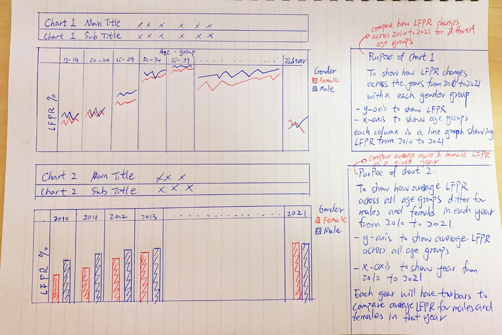

### 2.1 Clarity

1. The chart title will be comprehensive and include all important information of the visualisation. For example, “Singapore resident labour force participation rate (LFPR) by gender and age group from 2010 to 2021” will be used to allow users to understand the context and time period of the graph.
2. Horizontal axis will be sorted in ascending order for the age groups from “15 to 19” to “75 and over” to allow more meaningful comparison across age groups. In addition, overlapping age groups such as “70 and over” will be removed.
3. To allow more insightful analysis, males and females will be separated using different colours to allow users to spot different trends in LFPR for different genders across the years. If we aggregate the data and do not separate by genders, important trend could be missed as the male and female LFPR may demonstrate different trends over the years.
4. To allow comparison between different genders in a given year, a second chart will be created using side by side bars to visualise average LFPR across all age groups in a given year for males and femalels respectively. This additional graph will ensure a more holistic analysis across the given time frame.

### 2.2 Aesthetics

1. Only two colours will be used to represent males and females data respectively. The removal of redundant colours will allow viewers to focus on trend analysis while avoid being disturbed by the confusing colour shadings.
2. The words “Males” and “females” in the chart titles will be shaded using the respective legend colour to ensure consistency.
3. Labels and column widths will be adjusted accordingly to ensure no words are blocked.

# 3 Proposed Visualisation

Please refer to the graph below for poposed visualisation. You can also find it on [Tableau Public](https://public.tableau.com/app/profile/fei.jiahui/viz/DataVizMakeover1_16441735384140/Dashboard1).

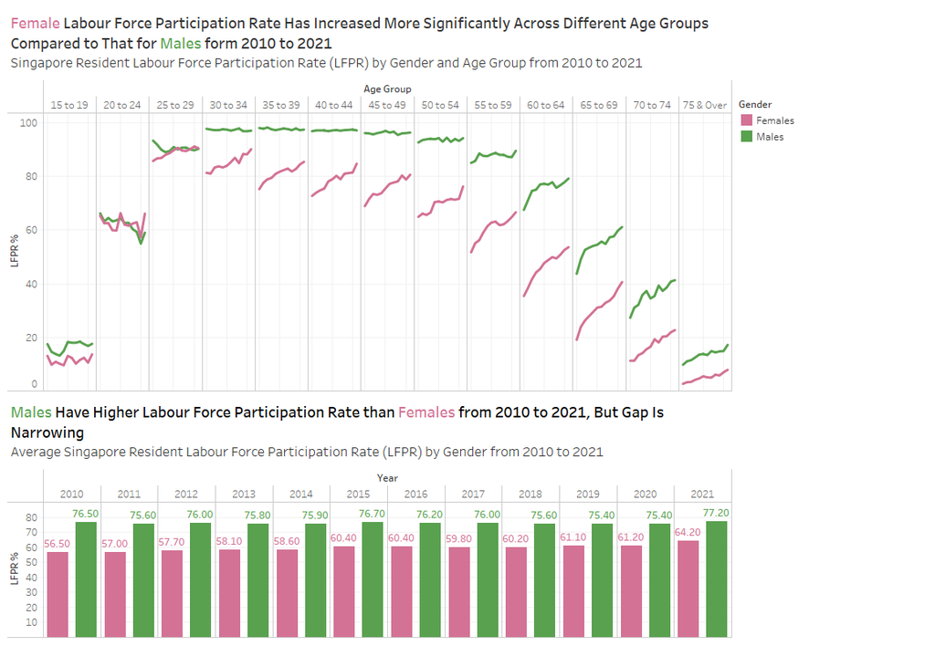

# 4 Step By Step Guide

Step

Action

1. Open the downloaded data source excel file, create a new worksheet. Create four columns, name them as “Gender”, “Age group”, “Year” and “LFPR”.

[figure not shown]

2. Under **gender** column, create 3 groups for “All”, “males” and “females”. Under **age group** column, copy the age groups from sheet “mrsd_Res_LFPR_2”, Fill the **year** column with years ranging from 2010 to 2021. Lastly, copy the LFPR for the respective gender, age groups and year over from sheet “mrsd_Res_LFPR_2” to the **LFPR** column.

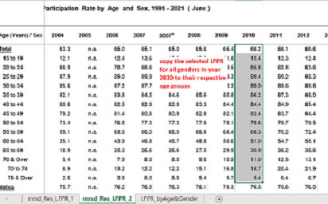

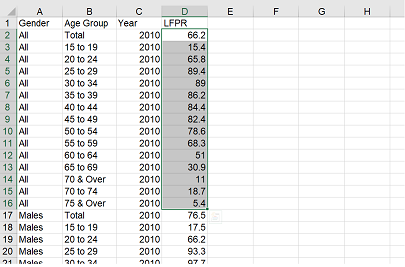

3. Open tableau, drag the exel file to tableau, then drag the sheet we created “LFPR_byAge&Gender” to the data source page

[figure not shown]

4. Drag Age group and year to columns, Lfpr to rows and gender to colours

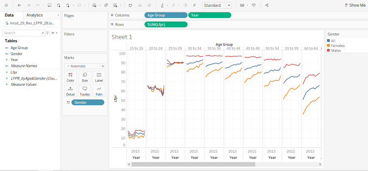

5. Next, we need to remove the age group “70 and above”. To do this, we drag age group to Filters and deselect the box “70 and above”, we also remove the age group for “total”, which shows the average LFPR across all age groups.

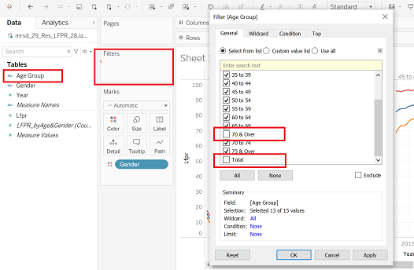

6. We need only male and female LFPR, hence we drag gender to filters and remove “total” which is showing average LFPR across all genders.

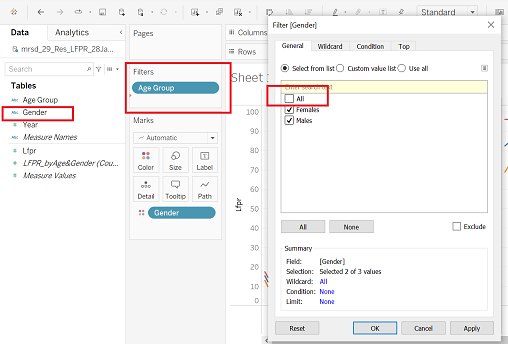

7. We then change the colours for males and females by clicking colour, then click edit coulour, choose Tableau 20. We will choose pink for females and green for males.

[figure not shown]

8. Next, we will remove the horizontal axis label for years at the bottom, since the time frame information will be described in the chart title and for this chart, the purpose is to show different LFPR trends across different age groups in the same time frame, it is not necessary to show the years repeatedly at the bottom. We click the year then untick show header.

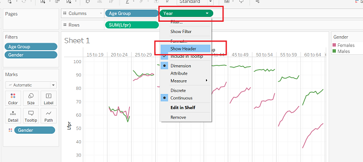

9. We will change the chart title as shown in the graph, change the clolours for males and females to that of the legend, bold the main chart title.

[figure not shown]

10. Edit vertical axis title by right click the axis, select edit axis, then change the axis title.

[figure not shown]

11. Change font size of the axis labels by right clicking the label, select format, then change the font size to 6. Do the same for horizontal axis

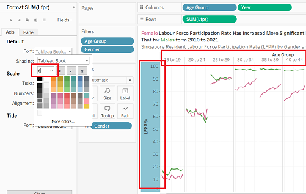

12. Create a new worksheet for chart 2, drage gender and year to columns, Lfpr to rows and gender to colours.

[figure not shown]

13. Drag age group to filters, select only total to show average LFPR across all age groups.

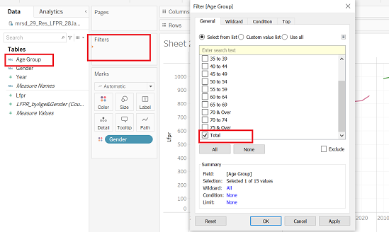

14. Drag gender to filter, deselect “All” to show only Male and Female LFPR.

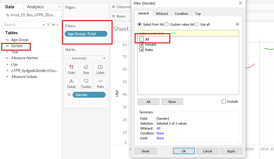

15. To create the side-by-side by chart, we change the data type for year to string, then drag it in front of gender in columns.

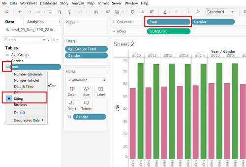

16. We have to go back to sheet 1 to change the data type for year from string to number.

[figure not shown]

17. Next, we remove bottom horizontal axis label by deselecting show header for gender.

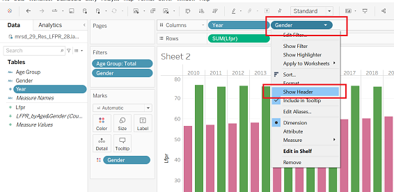

18. We will add labels on top of each bar. Click Label then tick show mark labels.

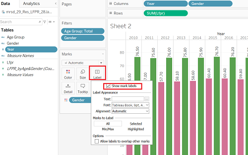

19. we will match mark colour with legend and resize the font of the mark labels,

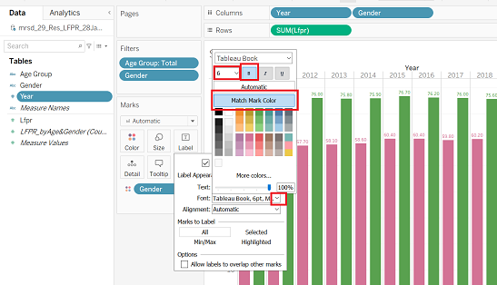

20. Similar to chart 1, we will edit vertical axis title and reformat all the label fonts.

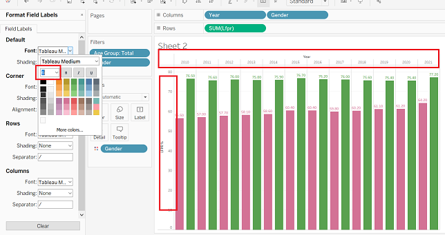

21. We will then edit chart title for chart 2.

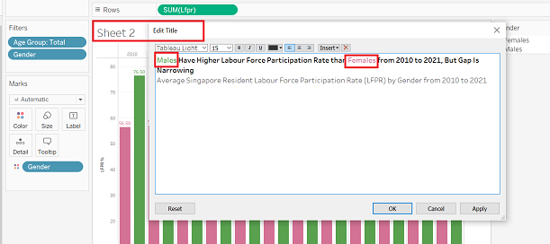

22. Create a new dashboard, drag sheet1 and sheet2 over.

[figure not shown]

23. Finally, drag a blank box to upper right corner to move down the legend box, also move the mouse cursor to chart boarder to adjust the width for chart 1 and 2.

[figure not shown]

# 5 Observations and Insights

### 5.1 Male and Female LFPRs diverges at around the age of 30

From the chart below, we can see LFPR for males and females do not differ much before the age of 30. However, from the age of 30, males have significantly higher labour force participation rate.

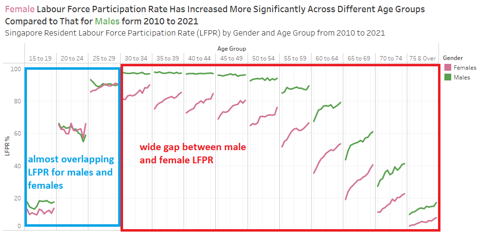

One possible explanation for this observation is that women are more likely to leave the labour force after marriage than men do.

According to [Singapore Government](https://www.strategygroup.gov.sg/images/Press%20Release%20images/PDFs/marriage-and-parenthood-trends-in-singapore.pdf) statistics, median age at first marriage is at 30.1 for men and 27.8 for woman in 2011. The median age at first birth is 29.8 for Singaporean mothers. Also, according to [Ministry of Social and Family Development](https://www.msf.gov.sg/research-and-data/Research-and-Data-Series/Documents/Family%20and%20Work%20Report.pdf), among those who cited housework, childcare and caregiving to families or relatives as the main reason for not working, women formed the majority with 99.5%, 97.4% and 84.3% respectively.

As a result, woman are more likely to drop out from the labour force after marriage and giving birth, and this explains why the male and female labour force participation rate start to diverge at the age of around 30.

### 5.2 Female LFPR increased more significantly over the years

Another trend is that female LFPR has increased more significantly over the year across most age groups. For example, the male LFPR line almost stays flat for age groups 30 to 59 from 2010 to 2021, while that for female LFPR show a steep upward trend in the same period from 2010 to 2021.

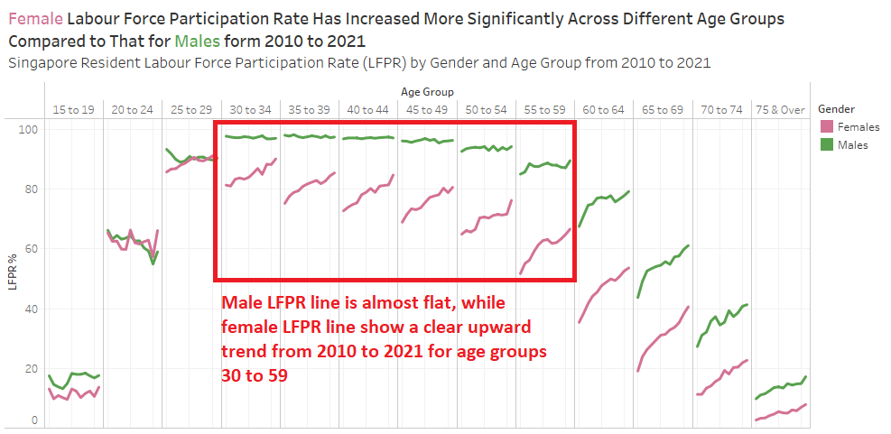

This can also be shown from the difference between average male and female LFPRs over the years. For example, in 2010, average male LFPR is 20 percentage points higher than that for females, while the gap has narrowed to 13 percentage points in 2021.

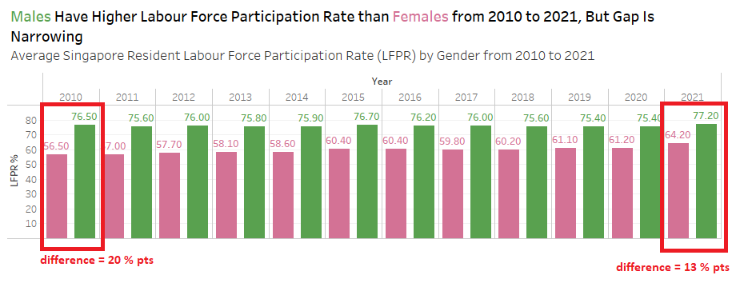

According to [Ministry of Manpower](https://stats.mom.gov.sg/Pages/a-gender-inclusive-workforce.aspx), more women are joining the workforce and subscribing to more financially independent lifestyles over the years.

In addition, the covid pandemic also helped women to participate in the workforce. From the chart above, we can see that average female LFPR has increased significantly from 61.2% to 64.2% between 2020 and 2021, this is contributed by more flexible woring arrangements brought by covid control measures. As more women can choose to work from home, they are more likely to be able to balance their work and family responsibilities. Hence, more women are encouraged to join or stay in the workforce and the female LFPR increased significantly.

### 5.3 Elderly aged 55 and above has the most significant increase in LFPR

From the chart below, we can see that elderly age groups (55 and above) see the most significant increase in LFPR over the years.

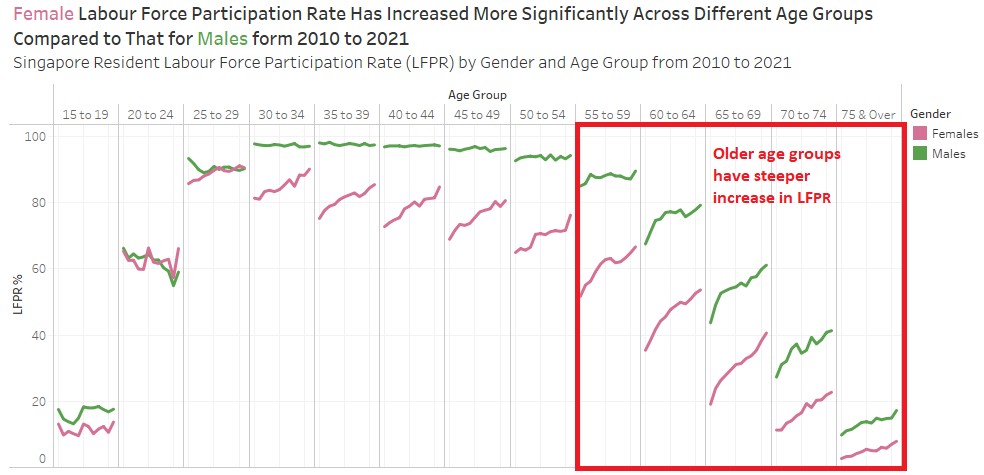

This observation is supported by data obtained from [Ministry of Manpower](https://stats.mom.gov.sg/Pages/Growing_Alongside_Our_Ageing_Workforce.aspx) which states that the share of labour force for those aged 55 and older has increased from 16.5% in 2010 to 25.7% in 2020.

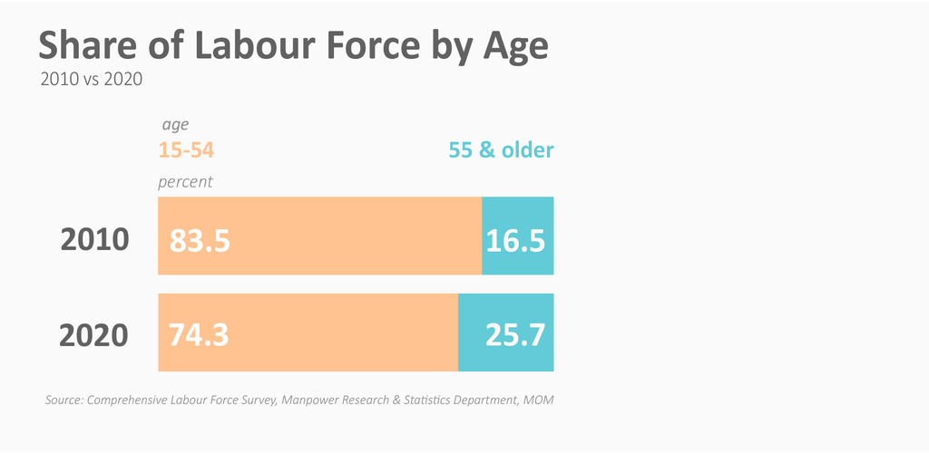

Besides the general demographic changes which suggests that the Singaporean workforce is growing older over the years, the various government support measures and initiatives have contributed to the significantly higher elderly LFPR. For example, the government has rolled out initiatives such as the Special Employment Credit in 2011, WorkPro Age Management Grant in 2013 and Senior Worker Support Package in 2020 to help senior workers stay employed and participate in the labour force. This has contributed to a higher LFPR for those aged 55 and above.